# EDA

# Introduction/ purpose

When giving out home loans, it is in the best interest of everyone to acurately predict those who will make payments and those who will default. THe purpose of this project is to identify who should get a loan while avoiding turning down people who would be able to pay off a loan. This EDA notebook is an initial exploration of the data. The main question this is attempting to uncover is, ” What is the best predictor or predictors of default?” It also looks at missing data and potential solutions, general correlations, and a brief exploration of joining with other data sets. questions to explore: What does the data look like? What is the data type? Is there a lot of missing data? Can it be deleted? Is it necessary? What seem to be the highest correlations and strongest predictors? Is any of our data weird, and how can we fix it? Does adding another data set help or create more noise? ## Load and view data

```r
# load data sets and packages
train <- read.csv("C:/Users/green/Downloads/home-credit-default-risk/application_train.csv")
test <- read.csv("C:/Users/green/Downloads/home-credit-default-risk/application_test.csv")

library(tidyverse)
library(skimr)
library(janitor)
library(dplyr)

#initial look at data
summary(train)
```

```
   SK_ID_CURR         TARGET        NAME_CONTRACT_TYPE CODE_GENDER
 Min.   :100002   Min.   :0.00000   Length:307511      Length:307511
 1st Qu.:189146   1st Qu.:0.00000   Class :character   Class :character
 Median :278202   Median :0.00000   Mode  :character   Mode  :character
 Mean   :278181   Mean   :0.08073
 3rd Qu.:367143   3rd Qu.:0.00000
 Max.   :456255   Max.   :1.00000

 FLAG_OWN_CAR       FLAG_OWN_REALTY     CNT_CHILDREN     AMT_INCOME_TOTAL
 Length:307511      Length:307511      Min.   : 0.0000   Min.   :    25650
 Class :character   Class :character   1st Qu.: 0.0000   1st Qu.:   112500
 Mode  :character   Mode  :character   Median : 0.0000   Median :   147150
                                       Mean   : 0.4171   Mean   :   168798
                                       3rd Qu.: 1.0000   3rd Qu.:   202500
                                       Max.   :19.0000   Max.   :117000000

   AMT_CREDIT       AMT_ANNUITY     AMT_GOODS_PRICE   NAME_TYPE_SUITE
 Min.   :  45000   Min.   :  1616   Min.   :  40500   Length:307511
 1st Qu.: 270000   1st Qu.: 16524   1st Qu.: 238500   Class :character
 Median : 513531   Median : 24903   Median : 450000   Mode  :character
 Mean   : 599026   Mean   : 27109   Mean   : 538396
 3rd Qu.: 808650   3rd Qu.: 34596   3rd Qu.: 679500
 Max.   :4050000   Max.   :258026   Max.   :4050000
                   NA's   :12       NA's   :278
 NAME_INCOME_TYPE   NAME_EDUCATION_TYPE NAME_FAMILY_STATUS NAME_HOUSING_TYPE
 Length:307511      Length:307511       Length:307511      Length:307511
 Class :character   Class :character    Class :character   Class :character
 Mode  :character   Mode  :character    Mode  :character   Mode  :character




 REGION_POPULATION_RELATIVE   DAYS_BIRTH     DAYS_EMPLOYED    DAYS_REGISTRATION
 Min.   :0.00029            Min.   :-25229   Min.   :-17912   Min.   :-24672
 1st Qu.:0.01001            1st Qu.:-19682   1st Qu.: -2760   1st Qu.: -7480
 Median :0.01885            Median :-15750   Median : -1213   Median : -4504
 Mean   :0.02087            Mean   :-16037   Mean   : 63815   Mean   : -4986
 3rd Qu.:0.02866            3rd Qu.:-12413   3rd Qu.:  -289   3rd Qu.: -2010
 Max.   :0.07251            Max.   : -7489   Max.   :365243   Max.   :     0

```

[output cut: 225 more lines]

```
 Min.   :0.00               Min.   : 0.00             Min.   :  0.00
 1st Qu.:0.00               1st Qu.: 0.00             1st Qu.:  0.00
 Median :0.00               Median : 0.00             Median :  0.00
 Mean   :0.03               Mean   : 0.27             Mean   :  0.27
 3rd Qu.:0.00               3rd Qu.: 0.00             3rd Qu.:  0.00
 Max.   :8.00               Max.   :27.00             Max.   :261.00
 NA's   :41519              NA's   :41519             NA's   :41519
 AMT_REQ_CREDIT_BUREAU_YEAR
 Min.   : 0.0
 1st Qu.: 0.0
 Median : 1.0
 Mean   : 1.9
 3rd Qu.: 3.0
 Max.   :25.0
 NA's   :41519
```

```r
glimpse(train)
```

```
Rows: 307,511
Columns: 122
$ SK_ID_CURR                   <int> 100002, 100003, 100004, 100006, 100007, 1…
$ TARGET                       <int> 1, 0, 0, 0, 0, 0, 0, 0, 0, 0, 0, 0, 0, 0,…
$ NAME_CONTRACT_TYPE           <chr> "Cash loans", "Cash loans", "Revolving lo…
$ CODE_GENDER                  <chr> "M", "F", "M", "F", "M", "M", "F", "M", "…
$ FLAG_OWN_CAR                 <chr> "N", "N", "Y", "N", "N", "N", "Y", "Y", "…
$ FLAG_OWN_REALTY              <chr> "Y", "N", "Y", "Y", "Y", "Y", "Y", "Y", "…
$ CNT_CHILDREN                 <int> 0, 0, 0, 0, 0, 0, 1, 0, 0, 0, 1, 0, 0, 1,…
$ AMT_INCOME_TOTAL             <dbl> 202500.00, 270000.00, 67500.00, 135000.00…
$ AMT_CREDIT                   <dbl> 406597.5, 1293502.5, 135000.0, 312682.5, …
$ AMT_ANNUITY                  <dbl> 24700.5, 35698.5, 6750.0, 29686.5, 21865.…
$ AMT_GOODS_PRICE              <dbl> 351000, 1129500, 135000, 297000, 513000, …
$ NAME_TYPE_SUITE              <chr> "Unaccompanied", "Family", "Unaccompanied…
$ NAME_INCOME_TYPE             <chr> "Working", "State servant", "Working", "W…
```

[output cut: 109 more lines]

```r
str(train)
```

```
'data.frame':   307511 obs. of  122 variables:
 $ SK_ID_CURR                  : int  100002 100003 100004 100006 100007 100008 100009 100010 100011 100012 ...
 $ TARGET                      : int  1 0 0 0 0 0 0 0 0 0 ...
 $ NAME_CONTRACT_TYPE          : chr  "Cash loans" "Cash loans" "Revolving loans" "Cash loans" ...
 $ CODE_GENDER                 : chr  "M" "F" "M" "F" ...
 $ FLAG_OWN_CAR                : chr  "N" "N" "Y" "N" ...
 $ FLAG_OWN_REALTY             : chr  "Y" "N" "Y" "Y" ...
 $ CNT_CHILDREN                : int  0 0 0 0 0 0 1 0 0 0 ...
 $ AMT_INCOME_TOTAL            : num  202500 270000 67500 135000 121500 ...
 $ AMT_CREDIT                  : num  406598 1293503 135000 312683 513000 ...
 $ AMT_ANNUITY                 : num  24701 35699 6750 29687 21866 ...
 $ AMT_GOODS_PRICE             : num  351000 1129500 135000 297000 513000 ...
 $ NAME_TYPE_SUITE             : chr  "Unaccompanied" "Family" "Unaccompanied" "Unaccompanied" ...
 $ NAME_INCOME_TYPE            : chr  "Working" "State servant" "Working" "Working" ...
 $ NAME_EDUCATION_TYPE         : chr  "Secondary / secondary special" "Higher education" "Secondary / secondary special" "Secondary / secondary special" ...
```

[output cut: 86 more lines]

```r
glimpse(test)
```

```
Rows: 48,744
Columns: 121
$ SK_ID_CURR                   <int> 100001, 100005, 100013, 100028, 100038, 1…
$ NAME_CONTRACT_TYPE           <chr> "Cash loans", "Cash loans", "Cash loans",…
$ CODE_GENDER                  <chr> "F", "M", "M", "F", "M", "F", "M", "M", "…
$ FLAG_OWN_CAR                 <chr> "N", "N", "Y", "N", "Y", "Y", "Y", "N", "…
$ FLAG_OWN_REALTY              <chr> "Y", "Y", "Y", "Y", "N", "Y", "Y", "Y", "…
$ CNT_CHILDREN                 <int> 0, 0, 0, 2, 1, 0, 2, 0, 0, 1, 0, 0, 0, 0,…
$ AMT_INCOME_TOTAL             <dbl> 135000, 99000, 202500, 315000, 180000, 27…
$ AMT_CREDIT                   <dbl> 568800.0, 222768.0, 663264.0, 1575000.0, …
$ AMT_ANNUITY                  <dbl> 20560.5, 17370.0, 69777.0, 49018.5, 32067…
$ AMT_GOODS_PRICE              <dbl> 450000, 180000, 630000, 1575000, 625500, …
$ NAME_TYPE_SUITE              <chr> "Unaccompanied", "Unaccompanied", "", "Un…
$ NAME_INCOME_TYPE             <chr> "Working", "Working", "Working", "Working…
$ NAME_EDUCATION_TYPE          <chr> "Higher education", "Secondary / secondar…
```

[output cut: 108 more lines]

```r
summary(test)
```

```
   SK_ID_CURR     NAME_CONTRACT_TYPE CODE_GENDER        FLAG_OWN_CAR
 Min.   :100001   Length:48744       Length:48744       Length:48744
 1st Qu.:188558   Class :character   Class :character   Class :character
 Median :277549   Mode  :character   Mode  :character   Mode  :character
 Mean   :277797
 3rd Qu.:367556
 Max.   :456250

 FLAG_OWN_REALTY     CNT_CHILDREN     AMT_INCOME_TOTAL    AMT_CREDIT
 Length:48744       Min.   : 0.0000   Min.   :  26942   Min.   :  45000
 Class :character   1st Qu.: 0.0000   1st Qu.: 112500   1st Qu.: 260640
 Mode  :character   Median : 0.0000   Median : 157500   Median : 450000
                    Mean   : 0.3971   Mean   : 178432   Mean   : 516740
                    3rd Qu.: 1.0000   3rd Qu.: 225000   3rd Qu.: 675000
                    Max.   :20.0000   Max.   :4410000   Max.   :2245500

  AMT_ANNUITY     AMT_GOODS_PRICE   NAME_TYPE_SUITE    NAME_INCOME_TYPE
 Min.   :  2295   Min.   :  45000   Length:48744       Length:48744
 1st Qu.: 17973   1st Qu.: 225000   Class :character   Class :character
 Median : 26199   Median : 396000   Mode  :character   Mode  :character
 Mean   : 29426   Mean   : 462619
 3rd Qu.: 37391   3rd Qu.: 630000
 Max.   :180576   Max.   :2245500
 NA's   :24
 NAME_EDUCATION_TYPE NAME_FAMILY_STATUS NAME_HOUSING_TYPE
 Length:48744        Length:48744       Length:48744
 Class :character    Class :character   Class :character
 Mode  :character    Mode  :character   Mode  :character




 REGION_POPULATION_RELATIVE   DAYS_BIRTH     DAYS_EMPLOYED    DAYS_REGISTRATION
 Min.   :0.000253           Min.   :-25195   Min.   :-17463   Min.   :-23722
 1st Qu.:0.010006           1st Qu.:-19637   1st Qu.: -2910   1st Qu.: -7459
 Median :0.018850           Median :-15785   Median : -1293   Median : -4490
 Mean   :0.021226           Mean   :-16068   Mean   : 67485   Mean   : -4968
 3rd Qu.:0.028663           3rd Qu.:-12496   3rd Qu.:  -296   3rd Qu.: -1901
 Max.   :0.072508           Max.   : -7338   Max.   :365243   Max.   :     0

```

[output cut: 217 more lines]

```
 Min.   :0.000              Min.   :0.000             Min.   :0.000
 1st Qu.:0.000              1st Qu.:0.000             1st Qu.:0.000
 Median :0.000              Median :0.000             Median :0.000
 Mean   :0.003              Mean   :0.009             Mean   :0.547
 3rd Qu.:0.000              3rd Qu.:0.000             3rd Qu.:1.000
 Max.   :2.000              Max.   :6.000             Max.   :7.000
 NA's   :6049               NA's   :6049              NA's   :6049
 AMT_REQ_CREDIT_BUREAU_YEAR
 Min.   : 0.000
 1st Qu.: 0.000
 Median : 2.000
 Mean   : 1.984
 3rd Qu.: 3.000
 Max.   :17.000
 NA's   :6049
```

# Data Description

The data consits of information about specific loan applicants. These variables include demographic, application, financial history, and repayment behaviors. Each row in the data represents the applicant/client. The TARGET is the most important variable in this data set as it is what we are trying to predict. The target is abinary variable if the applicant defaulted (1) or repaid the loan (0).There are also a few data sets outside training and testing that can be joined.

## explore relationships

```r
#target exploration
targetcount <- table(train$TARGET)
proportions <- prop.table(targetcount)

proportions <- prop.table(targetcount)

print(targetcount)
```

```
     0      1
282686  24825
```

```r
print(proportions)
```

```
         0          1
0.91927118 0.08072882
```

```r
#look for correlations
numeric_vars <- train[sapply(train, is.numeric)]
correlations <- cor(numeric_vars, use = "pairwise.complete.obs")
cor_matrix_clean <- correlations[complete.cases(correlations), complete.cases(t(correlations))]


target_corr <- correlations[,"TARGET"]
target_sorted <- sort(target_corr, decreasing = TRUE)

head(target_sorted, 10)
```

```
                     TARGET                  DAYS_BIRTH
                 1.00000000                  0.07823931
REGION_RATING_CLIENT_W_CITY        REGION_RATING_CLIENT
                 0.06089267                  0.05889901
     DAYS_LAST_PHONE_CHANGE             DAYS_ID_PUBLISH
                 0.05521848                  0.05145717
     REG_CITY_NOT_WORK_CITY              FLAG_EMP_PHONE
                 0.05099446                  0.04598222
     REG_CITY_NOT_LIVE_CITY             FLAG_DOCUMENT_3
                 0.04439537                  0.04434635
```

```r
tail(target_sorted, 10)
```

```
             ELEVATORS_AVG REGION_POPULATION_RELATIVE
               -0.03419879                -0.03722715
           AMT_GOODS_PRICE             FLOORSMAX_MODE
               -0.03964528                -0.04322626
            FLOORSMAX_MEDI              FLOORSMAX_AVG
               -0.04376792                -0.04400337
             DAYS_EMPLOYED               EXT_SOURCE_1
               -0.04493166                -0.15531713
              EXT_SOURCE_2               EXT_SOURCE_3
               -0.16047167                -0.17891870
```

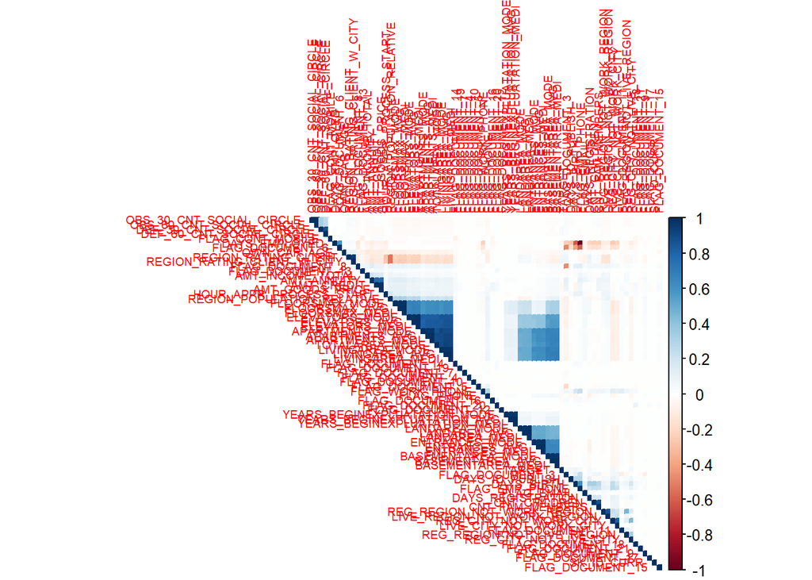

```r
library(corrplot)
target_corr_no_target <- target_corr[names(target_corr) != "TARGET"]
top_vars <- names(sort(abs(target_corr_no_target), decreasing = TRUE))[1:10]
vars_to_plot <- c("TARGET", top_vars)
cor_subset <- correlations[vars_to_plot, vars_to_plot]

#too many variables on visual, narrow it down to most important
corrplot(cor_matrix_clean, method = "color", tl.cex = 0.6, type = "upper", order = "hclust")
```

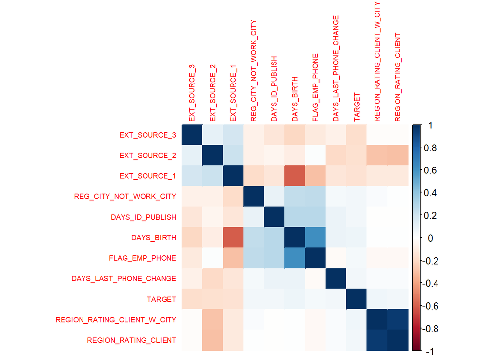

```r
plot.new()
corrplot(cor_subset, method = "color", tl.cex = 0.6, order = "hclust")
```

The target count shows us that 92% are non defualters. This is high enought that prediction methods would predict that nobody defaults.

## Missing Values

```r
library(corrr)
missing <- train %>% summarise(across(everything(), ~mean(is.na(.)))) %>% pivot_longer(everything(), names_to = "variable", values_to = "missing_pct") %>% arrange(desc(missing_pct))

missing %>% filter(missing_pct > 0.1)
```

```
# A tibble: 52 × 2
   variable                 missing_pct
   <chr>                          <dbl>
 1 COMMONAREA_AVG                 0.699
 2 COMMONAREA_MODE                0.699
 3 COMMONAREA_MEDI                0.699
 4 NONLIVINGAPARTMENTS_AVG        0.694
 5 NONLIVINGAPARTMENTS_MODE       0.694
 6 NONLIVINGAPARTMENTS_MEDI       0.694
 7 LIVINGAPARTMENTS_AVG           0.684
 8 LIVINGAPARTMENTS_MODE          0.684
 9 LIVINGAPARTMENTS_MEDI          0.684
10 FLOORSMIN_AVG                  0.678
# ℹ 42 more rows
```

```r
#missing above .6
high_missing_cols <- c(
  "COMMONAREA_AVG", "COMMONAREA_MODE", "COMMONAREA_MEDI",
  "NONLIVINGAPARTMENTS_AVG", "NONLIVINGAPARTMENTS_MODE", "NONLIVINGAPARTMENTS_MEDI",
  "LIVINGAPARTMENTS_AVG", "LIVINGAPARTMENTS_MODE", "LIVINGAPARTMENTS_MEDI",
  "FLOORSMIN_AVG", "FLOORSMIN_MODE", "FLOORSMIN_MEDI",
  "YEARS_BUILD_AVG", "YEARS_BUILD_MODE",
"YEARS_BUILD_MEDI", "OWN_CAR_AGE"
)

subset_train <- train %>%
  select(SK_ID_CURR, TARGET, all_of(high_missing_cols))

#testing for correlation
cor_df <- subset_train %>%
  select(-SK_ID_CURR) %>%
  correlate() %>%
  focus(TARGET) %>%
  arrange(desc(abs(TARGET)))

print(cor_df)
```

```
# A tibble: 16 × 2
   term                       TARGET
   <chr>                       <dbl>
 1 OWN_CAR_AGE               0.0376
 2 FLOORSMIN_AVG            -0.0336
 3 FLOORSMIN_MEDI           -0.0334
 4 FLOORSMIN_MODE           -0.0327
 5 LIVINGAPARTMENTS_AVG     -0.0250
 6 LIVINGAPARTMENTS_MEDI    -0.0246
 7 LIVINGAPARTMENTS_MODE    -0.0234
 8 YEARS_BUILD_MEDI         -0.0223
 9 YEARS_BUILD_AVG          -0.0221
10 YEARS_BUILD_MODE         -0.0221
11 COMMONAREA_MEDI          -0.0186
12 COMMONAREA_AVG           -0.0185
13 COMMONAREA_MODE          -0.0163
14 NONLIVINGAPARTMENTS_AVG  -0.00318
15 NONLIVINGAPARTMENTS_MEDI -0.00276
16 NONLIVINGAPARTMENTS_MODE -0.00156
```

```r
train <- train %>% select(-all_of(high_missing_cols))
test <- test %>% select(-all_of(high_missing_cols))

correlations_removed <- train %>%
  select(where(is.numeric)) %>%
  cor(use = "pairwise.complete.obs")

#remove misisng data with no correlation
target_corr <- abs(correlations_removed[ , "TARGET"])
target_corr <- target_corr[names(target_corr) != "TARGET"]

top_10_corr <- sort(target_corr, decreasing = TRUE)[1:10]

print(top_10_corr)
```

```
               EXT_SOURCE_3                EXT_SOURCE_2
                 0.17891870                  0.16047167
               EXT_SOURCE_1                  DAYS_BIRTH
                 0.15531713                  0.07823931
REGION_RATING_CLIENT_W_CITY        REGION_RATING_CLIENT
                 0.06089267                  0.05889901
     DAYS_LAST_PHONE_CHANGE             DAYS_ID_PUBLISH
                 0.05521848                  0.05145717
     REG_CITY_NOT_WORK_CITY              FLAG_EMP_PHONE
                 0.05099446                  0.04598222
```

# Missing data discussion

Many of the missing varibles can be dropped. They have a very high percentage of missing data, and are likely very correlated with each other. All the correlations with the target for variables missing more than 60% are all very low, and are not linear predictors. With non-linear models they will likely create a lot of noise. I feel comfortable dropping all of these variables. It is important to look at the nature of the “missing values”. Is it missing, or is it just null? An example of where this could matter is children. Leaving the children blank can’t just be removed because if the blank means that the applicant has 0 children, eliminating that isn’t appropriate as it could be a big predictor.

## strange values

```r
train %>%
  select_if(is.character) %>%
  summarise_all(n_distinct)
```

```
  NAME_CONTRACT_TYPE CODE_GENDER FLAG_OWN_CAR FLAG_OWN_REALTY NAME_TYPE_SUITE
1                  2           3            2               2               8
  NAME_INCOME_TYPE NAME_EDUCATION_TYPE NAME_FAMILY_STATUS NAME_HOUSING_TYPE
1                8                   5                  6                 6
  OCCUPATION_TYPE WEEKDAY_APPR_PROCESS_START ORGANIZATION_TYPE
1              19                          7                58
  FONDKAPREMONT_MODE HOUSETYPE_MODE WALLSMATERIAL_MODE EMERGENCYSTATE_MODE
1                  5              4                  8                   3
```

```r
near_zero <- train %>%
  summarise(across(everything(), ~length(unique(.)))) %>%
  pivot_longer(everything()) %>%
  filter(value <= 1)
```

## aggregate

```r
#add bureau data

bureau <- read_csv("C:\\Users\\green\\Downloads\\home-credit-default-risk\\bureau.csv")
bureau_train <- bureau %>%
  group_by(SK_ID_CURR) %>%
  summarise(
    n_bureau_loans = n(),
    avg_days_credit = mean(DAYS_CREDIT, na.rm = TRUE),
    max_credit_sum = max(AMT_CREDIT_SUM, na.rm = TRUE),
    active_loans = sum(CREDIT_ACTIVE == "Active", na.rm = TRUE)
  )

train_joined <- train %>%
  left_join(bureau_train, by = "SK_ID_CURR")

skim(train_joined)
```

Data summary

| Name | train_joined |
| --- | --- |
| Number of rows | 307511 |
| Number of columns | 110 |
| _______________________ |  |
| Column type frequency: |  |
| character | 16 |
| numeric | 94 |
| ________________________ |  |
| Group variables | None |

**Variable type: character**

| skim_variable | n_missing | complete_rate | min | max | empty | n_unique | whitespace |
| --- | --- | --- | --- | --- | --- | --- | --- |
| NAME_CONTRACT_TYPE | 0 | 1 | 10 | 15 | 0 | 2 | 0 |
| CODE_GENDER | 0 | 1 | 1 | 3 | 0 | 3 | 0 |
| FLAG_OWN_CAR | 0 | 1 | 1 | 1 | 0 | 2 | 0 |
| FLAG_OWN_REALTY | 0 | 1 | 1 | 1 | 0 | 2 | 0 |
| NAME_TYPE_SUITE | 0 | 1 | 0 | 15 | 1292 | 8 | 0 |
| NAME_INCOME_TYPE | 0 | 1 | 7 | 20 | 0 | 8 | 0 |
| NAME_EDUCATION_TYPE | 0 | 1 | 15 | 29 | 0 | 5 | 0 |
| NAME_FAMILY_STATUS | 0 | 1 | 5 | 20 | 0 | 6 | 0 |
| NAME_HOUSING_TYPE | 0 | 1 | 12 | 19 | 0 | 6 | 0 |
| OCCUPATION_TYPE | 0 | 1 | 0 | 21 | 96391 | 19 | 0 |
| WEEKDAY_APPR_PROCESS_START | 0 | 1 | 6 | 9 | 0 | 7 | 0 |
| ORGANIZATION_TYPE | 0 | 1 | 3 | 22 | 0 | 58 | 0 |
| FONDKAPREMONT_MODE | 0 | 1 | 0 | 21 | 210295 | 5 | 0 |
| HOUSETYPE_MODE | 0 | 1 | 0 | 16 | 154297 | 4 | 0 |
| WALLSMATERIAL_MODE | 0 | 1 | 0 | 12 | 156341 | 8 | 0 |
| EMERGENCYSTATE_MODE | 0 | 1 | 0 | 3 | 145755 | 3 | 0 |

**Variable type: numeric**

| skim_variable | n_missing | complete_rate | mean | sd | p0 | p25 | p50 | p75 | p100 | hist |
| --- | --- | --- | --- | --- | --- | --- | --- | --- | --- | --- |
| SK_ID_CURR | 0 | 1.00 | 278180.52 | 102790.18 | 100002.00 | 189145.50 | 278202.00 | 367142.50 | 456255.00 | ▇▇▇▇▇ |
| TARGET | 0 | 1.00 | 0.08 | 0.27 | 0.00 | 0.00 | 0.00 | 0.00 | 1.00 | ▇▁▁▁▁ |
| CNT_CHILDREN | 0 | 1.00 | 0.42 | 0.72 | 0.00 | 0.00 | 0.00 | 1.00 | 19.00 | ▇▁▁▁▁ |
| AMT_INCOME_TOTAL | 0 | 1.00 | 168797.92 | 237123.15 | 25650.00 | 112500.00 | 147150.00 | 202500.00 | 117000000.00 | ▇▁▁▁▁ |
| AMT_CREDIT | 0 | 1.00 | 599026.00 | 402490.78 | 45000.00 | 270000.00 | 513531.00 | 808650.00 | 4050000.00 | ▇▂▁▁▁ |
| AMT_ANNUITY | 12 | 1.00 | 27108.57 | 14493.74 | 1615.50 | 16524.00 | 24903.00 | 34596.00 | 258025.50 | ▇▁▁▁▁ |
| AMT_GOODS_PRICE | 278 | 1.00 | 538396.21 | 369446.46 | 40500.00 | 238500.00 | 450000.00 | 679500.00 | 4050000.00 | ▇▂▁▁▁ |
| REGION_POPULATION_RELATIVE | 0 | 1.00 | 0.02 | 0.01 | 0.00 | 0.01 | 0.02 | 0.03 | 0.07 | ▇▇▃▁▁ |
| DAYS_BIRTH | 0 | 1.00 | -16037.00 | 4363.99 | -25229.00 | -19682.00 | -15750.00 | -12413.00 | -7489.00 | ▃▆▇▇▅ |
| DAYS_EMPLOYED | 0 | 1.00 | 63815.05 | 141275.77 | -17912.00 | -2760.00 | -1213.00 | -289.00 | 365243.00 | ▇▁▁▁▂ |
| DAYS_REGISTRATION | 0 | 1.00 | -4986.12 | 3522.89 | -24672.00 | -7479.50 | -4504.00 | -2010.00 | 0.00 | ▁▁▂▅▇ |
| DAYS_ID_PUBLISH | 0 | 1.00 | -2994.20 | 1509.45 | -7197.00 | -4299.00 | -3254.00 | -1720.00 | 0.00 | ▁▆▇▆▅ |
| FLAG_MOBIL | 0 | 1.00 | 1.00 | 0.00 | 0.00 | 1.00 | 1.00 | 1.00 | 1.00 | ▁▁▁▁▇ |
| FLAG_EMP_PHONE | 0 | 1.00 | 0.82 | 0.38 | 0.00 | 1.00 | 1.00 | 1.00 | 1.00 | ▂▁▁▁▇ |
| FLAG_WORK_PHONE | 0 | 1.00 | 0.20 | 0.40 | 0.00 | 0.00 | 0.00 | 0.00 | 1.00 | ▇▁▁▁▂ |
| FLAG_CONT_MOBILE | 0 | 1.00 | 1.00 | 0.04 | 0.00 | 1.00 | 1.00 | 1.00 | 1.00 | ▁▁▁▁▇ |
| FLAG_PHONE | 0 | 1.00 | 0.28 | 0.45 | 0.00 | 0.00 | 0.00 | 1.00 | 1.00 | ▇▁▁▁▃ |
| FLAG_EMAIL | 0 | 1.00 | 0.06 | 0.23 | 0.00 | 0.00 | 0.00 | 0.00 | 1.00 | ▇▁▁▁▁ |
| CNT_FAM_MEMBERS | 2 | 1.00 | 2.15 | 0.91 | 1.00 | 2.00 | 2.00 | 3.00 | 20.00 | ▇▁▁▁▁ |
| REGION_RATING_CLIENT | 0 | 1.00 | 2.05 | 0.51 | 1.00 | 2.00 | 2.00 | 2.00 | 3.00 | ▁▁▇▁▂ |
| REGION_RATING_CLIENT_W_CITY | 0 | 1.00 | 2.03 | 0.50 | 1.00 | 2.00 | 2.00 | 2.00 | 3.00 | ▁▁▇▁▂ |
| HOUR_APPR_PROCESS_START | 0 | 1.00 | 12.06 | 3.27 | 0.00 | 10.00 | 12.00 | 14.00 | 23.00 | ▁▃▇▆▁ |
| REG_REGION_NOT_LIVE_REGION | 0 | 1.00 | 0.02 | 0.12 | 0.00 | 0.00 | 0.00 | 0.00 | 1.00 | ▇▁▁▁▁ |
| REG_REGION_NOT_WORK_REGION | 0 | 1.00 | 0.05 | 0.22 | 0.00 | 0.00 | 0.00 | 0.00 | 1.00 | ▇▁▁▁▁ |
| LIVE_REGION_NOT_WORK_REGION | 0 | 1.00 | 0.04 | 0.20 | 0.00 | 0.00 | 0.00 | 0.00 | 1.00 | ▇▁▁▁▁ |
| REG_CITY_NOT_LIVE_CITY | 0 | 1.00 | 0.08 | 0.27 | 0.00 | 0.00 | 0.00 | 0.00 | 1.00 | ▇▁▁▁▁ |
| REG_CITY_NOT_WORK_CITY | 0 | 1.00 | 0.23 | 0.42 | 0.00 | 0.00 | 0.00 | 0.00 | 1.00 | ▇▁▁▁▂ |
| LIVE_CITY_NOT_WORK_CITY | 0 | 1.00 | 0.18 | 0.38 | 0.00 | 0.00 | 0.00 | 0.00 | 1.00 | ▇▁▁▁▂ |
| EXT_SOURCE_1 | 173378 | 0.44 | 0.50 | 0.21 | 0.01 | 0.33 | 0.51 | 0.68 | 0.96 | ▂▇▇▇▃ |
| EXT_SOURCE_2 | 660 | 1.00 | 0.51 | 0.19 | 0.00 | 0.39 | 0.57 | 0.66 | 0.85 | ▂▂▃▇▃ |

[output cut: 64 more lines]

```r
train_joined %>%
  select(TARGET, avg_days_credit, max_credit_sum, n_bureau_loans) %>%
  cor(use = "pairwise.complete.obs")
```

```
                     TARGET avg_days_credit max_credit_sum n_bureau_loans
TARGET          1.000000000      0.08972897            NaN    0.004056091
avg_days_credit 0.089728967      1.00000000            NaN   -0.136546746
max_credit_sum          NaN             NaN            NaN            NaN
n_bureau_loans  0.004056091     -0.13654675            NaN    1.000000000
```

## exploring joined

```r
bureau_train <- bureau %>%
  group_by(SK_ID_CURR) %>%
  summarise(
    bureau_loan_count = n(),
    active_loans = sum(CREDIT_ACTIVE == "Active", na.rm = TRUE),
    closed_loans = sum(CREDIT_ACTIVE == "Closed", na.rm = TRUE),
    avg_days_credit = mean(DAYS_CREDIT, na.rm = TRUE),
    avg_credit_sum = mean(AMT_CREDIT_SUM, na.rm = TRUE),
    max_credit_sum = max(AMT_CREDIT_SUM, na.rm = TRUE),
    total_credit_sum = sum(AMT_CREDIT_SUM, na.rm = TRUE),
    avg_overdue = mean(AMT_CREDIT_SUM_OVERDUE, na.rm = TRUE)
  )
train_joined <- train %>%
  left_join(bureau_train, by = "SK_ID_CURR")

joined_corr <- train_joined %>%
  select(TARGET, bureau_loan_count:avg_overdue) %>%
  cor(use = "pairwise.complete.obs")

print(joined_corr[, "TARGET"])
```

```
           TARGET bureau_loan_count      active_loans      closed_loans
      1.000000000       0.004056091       0.067128153      -0.030812408
  avg_days_credit    avg_credit_sum    max_credit_sum  total_credit_sum
      0.089728967      -0.019956562               NaN      -0.014057226
      avg_overdue
      0.007150265
```

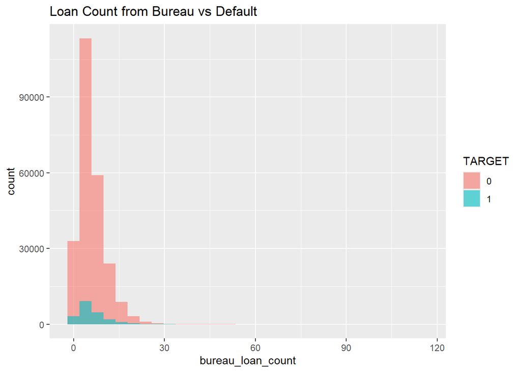

```r
library(ggplot2)

ggplot(train_joined, aes(x = bureau_loan_count, fill = factor(TARGET))) +
  geom_histogram(position = "identity", alpha = 0.6, bins = 30) +
  labs(title = "Loan Count from Bureau vs Default", fill = "TARGET")
```

active_loans and avg_days_credit seem to have some correlations

# Summary

The purpose of this exploration was not to deliver actionable insights or predictions. Rather, I worked with the data, massaged a few things, and got comfortable with what can be done with this data set. Some reoccuring themes and areas to focus on first came to light. Surface level, I think that these resuls of the highest Correlations with the target variable would be a great place to further explore.

```
           EXT_SOURCE_3                EXT_SOURCE_2
             0.17891870                  0.16047167
           EXT_SOURCE_1                  DAYS_BIRTH
             0.15531713                  0.07823931
```

From all of the different ways of looking at this data, it seems apparant that all of the EXT_SOURCE varibales are large predictors of a persons ability to repay a loan. These variables all come from “existing sources” such as prior loans or credit scores. It could be beneficial to create predictions of those variables to uncover intervals of people who are likely to default if they fall into that range. It seems that people who are older are less likely to default. Region of where the person works/lives also seems to present some risk in lending.

The Ai model provided a theoretical list of what will likely be a predictor of credit default. This is likely based on history and intuitive assumptions. There were a lot of commonalities in what I found such as Source (application and existing sourse), age, region, and factors tha appear to be important in data prediction. Alothough there were common themes, my exploration was more measureable while the AI was more conceptual. The Ai seemed to join and engineer variables, which is something I can further tease out while building models.

Even after removing variables with little to no correlation that were missing data, there are still a lot of variables that would be very noisy to build a model with. Further identifying ways to eliminate variables and clean up NA/missing values would be essential in making the best predictions. Analysis can be done, variables can be removed, and results can be compared to see what is more accurate. Some other next steps include: normalizing the different variables, creating categorical variables to better allign the data types, and finally building and evaluating several models.

# AI log

## prompt

Please act as a credit risk analyst and, based only on the semantic meanings of the variables, identify the top 15 to 20 variables you believe would be most predictive of default (TARGET = 1). Explain briefly why each selected variable could matter in predicting borrower default. use kaggle home default application_{train|test}.csv

## AI Response

Below is a reasoned “theoretical” ranking of ~ 15‑20 variables (or variable types / engineered metrics) from the *Home Credit: application_train/application_test + linked data* context that, based on their semantics, I would expect to be highly predictive of default (TARGET = 1). Because I don’t have the full schema in front of me here, some names are approximate (or refer to engineered aggregates from the auxiliary tables). But these are the kinds of features I would prioritize:

## Top Candidate Predictors of Default (by semantic importance)

1. **Debt-to-Income Ratio** (or *“total debt obligations / income”*)
   - A classic metric of capacity: if a large share of income is already committed to debt, the borrower has less room to absorb shocks, making default more likely.
2. **Loan-to-Value (LTV) or “amount applied / collateral or property value”**
   - The higher the leverage (i.e. how much is borrowed relative to the asset’s value), the greater the risk (less cushion to absorb declines).
3. **Annuity / Monthly Payment Burden** (i.e. *“annuity / income”* or *“monthly payment / income”*)
   - How large is the repayment burden relative to earnings—if very high, more fragile.
4. **Number of Past Delinquencies / Payment Overdues** (in bureau / installments)
   - Past behavior is a strong predictor: prior late payments or defaults indicate credit risk.
5. **Days Past Due (DPD) or Days Overdue Aggregates**
   - The magnitude or frequency of days overdue (e.g. average, maximum) captures severity of past delinquency.
6. **Number of Credit Lines / Number of Loans Held**
   - The more credit lines (especially active ones), the more exposure and complexity; also more potential correlation of stress across lines.
7. **Credit Utilization / Usage Ratio on Credit Cards**
   - If a borrower uses near the limit of available credit, it suggests strain or lack of buffer.
8. **Length of Credit History / Vintage of Oldest Account**
   - Longer history gives more signal; short history is riskier (less proven performance).
9. **Number of Previous Rejected Applications**
   - Many rejections may indicate credit difficulty, overly aggressive applications, or weak creditworthiness.
10. **Employment Stability / Length (e.g. days employed, years in current job)**
    - Stable employment suggests more reliable income; short or volatile employments raise risk.
11. **Age (or derived “age at loan end”)**
    - Very young or very old borrowers may have higher default risk (life-cycle risk, income instability, health, etc.).
12. **Number of Dependents / Family Size (or “number of children”)**
    - More dependents may stress finances, reducing disposable income for debt service.
13. **Housing Type / Home Ownership Status**
    - Owning vs renting, mortgage burden, housing cost pressure all influence financial resilience.
14. **Region / Geographical Risk / Macro Indicator (e.g. region’s unemployment)**
    - External environment matters: in weaker economic areas, default risk is higher.
15. **External Credit Bureau Score / Credit Report Aggregates**
    - If available, the borrower’s broader credit bureau metrics (e.g. total credit debt, number of bureau accounts, credit score) are strong predictors.
16. **Delinquency Rate Ratio: (number of months overdue) / (number of months active)**
    - A normalized measure of how “bad” the credit history is relative to its length.
17. **Time Since Last Delinquency or Time Since Last Credit Activity**
    - More time since negative event suggests recovery; a recent delinquency raises concern.
18. **Number of Open Installment Loans vs Revolving Loans**
    - The mix of loan types matters: installment-heavy debt may be less flexible than revolving credit, so a heavy installment burden is riskier.
19. **Aggregate Defaults or Overdue Amounts from Bureau / Other Institutions**
    - If the borrower has defaults or overdues in other institutions, that’s a red flag.
20. **Variance or Volatility in Payment Behavior (e.g. inconsistent payments over months)**
    - Fluctuating payment patterns (large swings) suggest instability, which may presage future default.

### Qualitative Rationale & Interactions

- **Behavioral / historical evidence** (e.g. past delinquencies, DPD, aggregate overdue) tends to dominate because it is directly predictive of future default.
- **Capacity metrics** (debt-to-income, annuity burden) calibrate how much stress a borrower can absorb.
- **Structural or constraint variables** (number of loans, utilization, loan‑to‑value, credit mix) create boundary risks.
- **Stability / resilience factors** (employment length, credit history length, housing) provide “buffers” against shocks.
- **Macro / external context** (region, external bureau data) capture systematic risk that is not captured in borrower’s internal data alone.

In practice, many Kaggle competitors working with the Home Credit dataset do precisely these kinds of aggregations from the auxiliary tables (bureau, previous applications, payment histories, credit card balances) and find that aggregated metrics like “sum of days overdue,” “count of past defaults,” “utilization ratio,” “number of past loans,” etc., often dominate feature‑importance rankings. ([GitHub](https://github.com/Bougeant/Home_Credit_default_risk?utm_source=chatgpt.com))

If you like, I can fetch the exact column names from the “application_train.csv + linked data” schema, and map this list to those names (so you get the top 15 columns by their actual names). Would you like me to do that?